# Risk Factor Analysis

## Outcome Variable

**Outcome Variable:** ever_stunted

## Predictor Variables

**Intervention Variable:** exclfeed3

**Adjustment Set:**

- arm
- W_mage
- meducyrs
- feducyrs
- hhwealth_quart
- hfoodsec
- W_mhtcm
- vagbrth
- W_gagebrth
- W_birthwt
- W_birthlen
- W_nrooms
- W_nchldlt5
- month
- brthmon
- W_parity
- impfloor
- impsan
- safeh20
- delta_W_mage
- delta_meducyrs
- delta_feducyrs
- delta_hhwealth_quart
- delta_hfoodsec
- delta_W_mhtcm
- delta_vagbrth
- delta_W_gagebrth
- delta_W_birthwt
- delta_W_birthlen
- delta_W_nrooms
- delta_W_nchldlt5
- delta_month
- delta_brthmon
- delta_W_parity
- delta_impfloor
- delta_impsan
- delta_safeh20

## Stratifying Variables

The analysis was stratified on these variable(s):

- agecat
- studyid
- country

## Data Summary

| agecat | studyid | country | exclfeed3 | ever_stunted | n_cell | n |
| --- | --- | --- | --- | --- | --- | --- |
| 0-24 months (no birth st.) | ki0047075b-MAL-ED | BANGLADESH | 1 | 0 | 71 | 206 |
| 0-24 months (no birth st.) | ki0047075b-MAL-ED | BANGLADESH | 1 | 1 | 80 | 206 |
| 0-24 months (no birth st.) | ki0047075b-MAL-ED | BANGLADESH | 0 | 0 | 27 | 206 |
| 0-24 months (no birth st.) | ki0047075b-MAL-ED | BANGLADESH | 0 | 1 | 28 | 206 |
| 0-24 months (no birth st.) | ki0047075b-MAL-ED | BRAZIL | 1 | 0 | 68 | 202 |
| 0-24 months (no birth st.) | ki0047075b-MAL-ED | BRAZIL | 1 | 1 | 10 | 202 |
| 0-24 months (no birth st.) | ki0047075b-MAL-ED | BRAZIL | 0 | 0 | 106 | 202 |
| 0-24 months (no birth st.) | ki0047075b-MAL-ED | BRAZIL | 0 | 1 | 18 | 202 |
| 0-24 months (no birth st.) | ki0047075b-MAL-ED | INDIA | 1 | 0 | 48 | 200 |
| 0-24 months (no birth st.) | ki0047075b-MAL-ED | INDIA | 1 | 1 | 74 | 200 |
| 0-24 months (no birth st.) | ki0047075b-MAL-ED | INDIA | 0 | 0 | 46 | 200 |
| 0-24 months (no birth st.) | ki0047075b-MAL-ED | INDIA | 0 | 1 | 32 | 200 |
| 0-24 months (no birth st.) | ki0047075b-MAL-ED | NEPAL | 1 | 0 | 59 | 209 |
| 0-24 months (no birth st.) | ki0047075b-MAL-ED | NEPAL | 1 | 1 | 22 | 209 |
| 0-24 months (no birth st.) | ki0047075b-MAL-ED | NEPAL | 0 | 0 | 95 | 209 |
| 0-24 months (no birth st.) | ki0047075b-MAL-ED | NEPAL | 0 | 1 | 33 | 209 |
| 0-24 months (no birth st.) | ki0047075b-MAL-ED | PERU | 1 | 0 | 24 | 251 |
| 0-24 months (no birth st.) | ki0047075b-MAL-ED | PERU | 1 | 1 | 33 | 251 |
| 0-24 months (no birth st.) | ki0047075b-MAL-ED | PERU | 0 | 0 | 77 | 251 |
| 0-24 months (no birth st.) | ki0047075b-MAL-ED | PERU | 0 | 1 | 117 | 251 |
| 0-24 months (no birth st.) | ki0047075b-MAL-ED | SOUTH AFRICA | 1 | 0 | 16 | 246 |
| 0-24 months (no birth st.) | ki0047075b-MAL-ED | SOUTH AFRICA | 1 | 1 | 15 | 246 |
| 0-24 months (no birth st.) | ki0047075b-MAL-ED | SOUTH AFRICA | 0 | 0 | 98 | 246 |
| 0-24 months (no birth st.) | ki0047075b-MAL-ED | SOUTH AFRICA | 0 | 1 | 117 | 246 |
| 0-24 months (no birth st.) | ki0047075b-MAL-ED | TANZANIA, UNITED REPUBLIC OF | 1 | 0 | 14 | 211 |
| 0-24 months (no birth st.) | ki0047075b-MAL-ED | TANZANIA, UNITED REPUBLIC OF | 1 | 1 | 48 | 211 |
| 0-24 months (no birth st.) | ki0047075b-MAL-ED | TANZANIA, UNITED REPUBLIC OF | 0 | 0 | 22 | 211 |
| 0-24 months (no birth st.) | ki0047075b-MAL-ED | TANZANIA, UNITED REPUBLIC OF | 0 | 1 | 127 | 211 |
| 0-24 months (no birth st.) | ki1000108-CMC-V-BCS-2002 | INDIA | 1 | 0 | 0 | 8 |
| 0-24 months (no birth st.) | ki1000108-CMC-V-BCS-2002 | INDIA | 1 | 1 | 8 | 8 |

[output cut: 162 more lines]

The following strata were considered:

- agecat: 0-24 months (no birth st.), studyid: ki0047075b-MAL-ED, country: BANGLADESH
- agecat: 0-24 months (no birth st.), studyid: ki0047075b-MAL-ED, country: BRAZIL
- agecat: 0-24 months (no birth st.), studyid: ki0047075b-MAL-ED, country: INDIA
- agecat: 0-24 months (no birth st.), studyid: ki0047075b-MAL-ED, country: NEPAL
- agecat: 0-24 months (no birth st.), studyid: ki0047075b-MAL-ED, country: PERU
- agecat: 0-24 months (no birth st.), studyid: ki0047075b-MAL-ED, country: SOUTH AFRICA
- agecat: 0-24 months (no birth st.), studyid: ki0047075b-MAL-ED, country: TANZANIA, UNITED REPUBLIC OF
- agecat: 0-24 months (no birth st.), studyid: ki1000108-CMC-V-BCS-2002, country: INDIA
- agecat: 0-24 months (no birth st.), studyid: ki1000108-IRC, country: INDIA
- agecat: 0-24 months (no birth st.), studyid: ki1000109-EE, country: PAKISTAN
- agecat: 0-24 months (no birth st.), studyid: ki1000304b-SAS-CompFeed, country: INDIA
- agecat: 0-24 months (no birth st.), studyid: ki1017093b-PROVIDE, country: BANGLADESH
- agecat: 0-24 months (no birth st.), studyid: ki1101329-Keneba, country: GAMBIA
- agecat: 0-24 months (no birth st.), studyid: ki1113344-GMS-Nepal, country: NEPAL
- agecat: 0-24 months (no birth st.), studyid: kiGH5241-JiVitA-3, country: BANGLADESH
- agecat: 0-24 months (no birth st.), studyid: kiGH5241-JiVitA-4, country: BANGLADESH
- agecat: 0-6 months (no birth st.), studyid: ki0047075b-MAL-ED, country: BANGLADESH
- agecat: 0-6 months (no birth st.), studyid: ki0047075b-MAL-ED, country: BRAZIL
- agecat: 0-6 months (no birth st.), studyid: ki0047075b-MAL-ED, country: INDIA
- agecat: 0-6 months (no birth st.), studyid: ki0047075b-MAL-ED, country: NEPAL
- agecat: 0-6 months (no birth st.), studyid: ki0047075b-MAL-ED, country: PERU
- agecat: 0-6 months (no birth st.), studyid: ki0047075b-MAL-ED, country: SOUTH AFRICA
- agecat: 0-6 months (no birth st.), studyid: ki0047075b-MAL-ED, country: TANZANIA, UNITED REPUBLIC OF
- agecat: 0-6 months (no birth st.), studyid: ki1000108-CMC-V-BCS-2002, country: INDIA
- agecat: 0-6 months (no birth st.), studyid: ki1000108-IRC, country: INDIA
- agecat: 0-6 months (no birth st.), studyid: ki1000109-EE, country: PAKISTAN
- agecat: 0-6 months (no birth st.), studyid: ki1000304b-SAS-CompFeed, country: INDIA
- agecat: 0-6 months (no birth st.), studyid: ki1017093b-PROVIDE, country: BANGLADESH
- agecat: 0-6 months (no birth st.), studyid: ki1101329-Keneba, country: GAMBIA
- agecat: 0-6 months (no birth st.), studyid: ki1113344-GMS-Nepal, country: NEPAL
- agecat: 0-6 months (no birth st.), studyid: kiGH5241-JiVitA-3, country: BANGLADESH
- agecat: 0-6 months (no birth st.), studyid: kiGH5241-JiVitA-4, country: BANGLADESH
- agecat: 6-24 months, studyid: ki0047075b-MAL-ED, country: BANGLADESH
- agecat: 6-24 months, studyid: ki0047075b-MAL-ED, country: BRAZIL
- agecat: 6-24 months, studyid: ki0047075b-MAL-ED, country: INDIA
- agecat: 6-24 months, studyid: ki0047075b-MAL-ED, country: NEPAL
- agecat: 6-24 months, studyid: ki0047075b-MAL-ED, country: PERU
- agecat: 6-24 months, studyid: ki0047075b-MAL-ED, country: SOUTH AFRICA
- agecat: 6-24 months, studyid: ki0047075b-MAL-ED, country: TANZANIA, UNITED REPUBLIC OF
- agecat: 6-24 months, studyid: ki1000108-CMC-V-BCS-2002, country: INDIA
- agecat: 6-24 months, studyid: ki1000108-IRC, country: INDIA
- agecat: 6-24 months, studyid: ki1000109-EE, country: PAKISTAN
- agecat: 6-24 months, studyid: ki1000304b-SAS-CompFeed, country: INDIA
- agecat: 6-24 months, studyid: ki1017093b-PROVIDE, country: BANGLADESH
- agecat: 6-24 months, studyid: ki1101329-Keneba, country: GAMBIA
- agecat: 6-24 months, studyid: ki1113344-GMS-Nepal, country: NEPAL
- agecat: 6-24 months, studyid: kiGH5241-JiVitA-3, country: BANGLADESH
- agecat: 6-24 months, studyid: kiGH5241-JiVitA-4, country: BANGLADESH

### Dropped Strata

Some strata were dropped due to rare outcomes:

- agecat: 0-24 months (no birth st.), studyid: ki1000108-CMC-V-BCS-2002, country: INDIA
- agecat: 0-24 months (no birth st.), studyid: ki1000108-IRC, country: INDIA
- agecat: 0-24 months (no birth st.), studyid: ki1000109-EE, country: PAKISTAN
- agecat: 0-24 months (no birth st.), studyid: kiGH5241-JiVitA-4, country: BANGLADESH
- agecat: 0-6 months (no birth st.), studyid: ki0047075b-MAL-ED, country: NEPAL
- agecat: 0-6 months (no birth st.), studyid: ki1000108-CMC-V-BCS-2002, country: INDIA
- agecat: 0-6 months (no birth st.), studyid: ki1000108-IRC, country: INDIA
- agecat: 0-6 months (no birth st.), studyid: kiGH5241-JiVitA-4, country: BANGLADESH
- agecat: 6-24 months, studyid: ki0047075b-MAL-ED, country: BRAZIL
- agecat: 6-24 months, studyid: ki1000108-CMC-V-BCS-2002, country: INDIA
- agecat: 6-24 months, studyid: ki1000108-IRC, country: INDIA
- agecat: 6-24 months, studyid: ki1000109-EE, country: PAKISTAN
- agecat: 6-24 months, studyid: ki1000304b-SAS-CompFeed, country: INDIA
- agecat: 6-24 months, studyid: kiGH5241-JiVitA-4, country: BANGLADESH

## Methods Detail

We’re interested in the causal parameters $E[Y_a]$ for all values of $a \in \mathcal{A}$. These parameters represent the mean outcome if, possibly contrary to fact, we intervened to set all units to have $A=a$. Under the randomization and positivity assumptions, these are identified by the statistical parameters $\psi_a=E_W[E_{Y|A,W}(Y|A=a,W)]$. In addition, we’re interested in the mean of $Y$, $E[Y]$ under no intervention (the observed mean). We will estimate these parameters by using SuperLearner to fit the relevant likelihood factors – $E_{Y|A,W}(Y|A=a,W)$ and $p(A=a|W)$, and then updating our likelihood fit using a joint TMLE.

For unadjusted analyses ($W=\{\}$), initial likelihoods were estimated using Lrnr_glm to estimate the simple $E(Y|A)$ and Lrnr_mean to estimate $p(A)$. For adjusted analyses, a small library containing Lrnr_glmnet, Lrnr_xgboost, and Lrnr_mean was used.

Having estimated these parameters, we will then use the delta method to estimate relative risks and attributable risks relative to a prespecified baseline level of $A$.

# Results Detail

## Results Plots

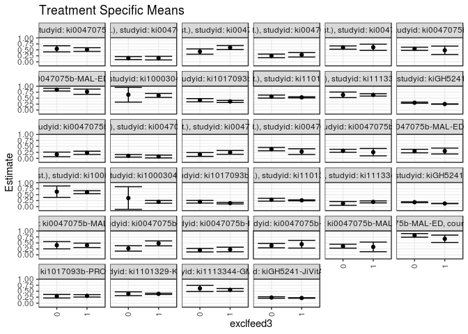

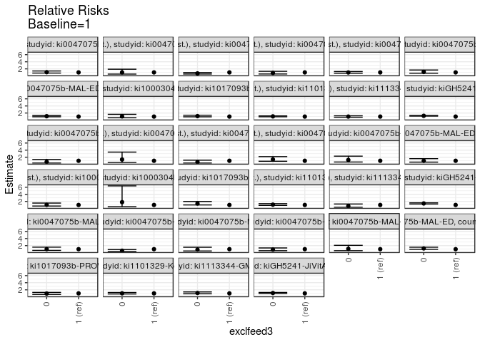

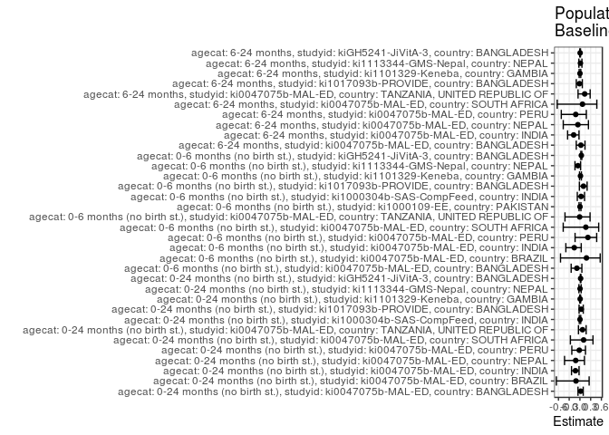

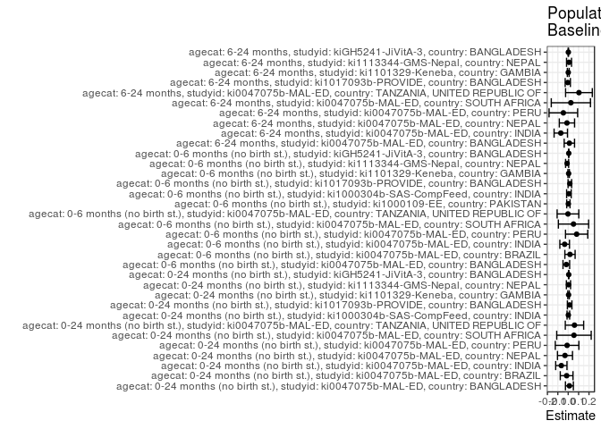

## Results Table

### Parameter: TSM

| agecat | studyid | country | intervention_level | baseline_level | estimate | ci_lower | ci_upper |
| --- | --- | --- | --- | --- | --- | --- | --- |
| 0-24 months (no birth st.) | ki0047075b-MAL-ED | BANGLADESH | 1 | NA | 0.5128213 | 0.4347696 | 0.5908729 |
| 0-24 months (no birth st.) | ki0047075b-MAL-ED | BANGLADESH | 0 | NA | 0.5446765 | 0.4163245 | 0.6730285 |
| 0-24 months (no birth st.) | ki0047075b-MAL-ED | BRAZIL | 1 | NA | 0.1537846 | 0.0788589 | 0.2287104 |
| 0-24 months (no birth st.) | ki0047075b-MAL-ED | BRAZIL | 0 | NA | 0.1538269 | 0.0915490 | 0.2161047 |
| 0-24 months (no birth st.) | ki0047075b-MAL-ED | INDIA | 1 | NA | 0.5962091 | 0.5114303 | 0.6809879 |
| 0-24 months (no birth st.) | ki0047075b-MAL-ED | INDIA | 0 | NA | 0.4284522 | 0.3165038 | 0.5404006 |
| 0-24 months (no birth st.) | ki0047075b-MAL-ED | NEPAL | 1 | NA | 0.2941815 | 0.1991927 | 0.3891703 |
| 0-24 months (no birth st.) | ki0047075b-MAL-ED | NEPAL | 0 | NA | 0.2485383 | 0.1738738 | 0.3232027 |
| 0-24 months (no birth st.) | ki0047075b-MAL-ED | PERU | 1 | NA | 0.6083355 | 0.4783095 | 0.7383614 |
| 0-24 months (no birth st.) | ki0047075b-MAL-ED | PERU | 0 | NA | 0.5977647 | 0.5290574 | 0.6664720 |
| 0-24 months (no birth st.) | ki0047075b-MAL-ED | SOUTH AFRICA | 1 | NA | 0.4812551 | 0.3035734 | 0.6589369 |
| 0-24 months (no birth st.) | ki0047075b-MAL-ED | SOUTH AFRICA | 0 | NA | 0.5451398 | 0.4784791 | 0.6118004 |
| 0-24 months (no birth st.) | ki0047075b-MAL-ED | TANZANIA, UNITED REPUBLIC OF | 1 | NA | 0.7690887 | 0.6596087 | 0.8785687 |
| 0-24 months (no birth st.) | ki0047075b-MAL-ED | TANZANIA, UNITED REPUBLIC OF | 0 | NA | 0.8543554 | 0.7981781 | 0.9105328 |
| 0-24 months (no birth st.) | ki1000304b-SAS-CompFeed | INDIA | 1 | NA | 0.6121795 | 0.5306906 | 0.6936683 |
| 0-24 months (no birth st.) | ki1000304b-SAS-CompFeed | INDIA | 0 | NA | 0.6428571 | 0.3329177 | 0.9527966 |
| 0-24 months (no birth st.) | ki1017093b-PROVIDE | BANGLADESH | 1 | NA | 0.3616937 | 0.3179881 | 0.4053994 |
| 0-24 months (no birth st.) | ki1017093b-PROVIDE | BANGLADESH | 0 | NA | 0.4119159 | 0.3441080 | 0.4797238 |
| 0-24 months (no birth st.) | ki1101329-Keneba | GAMBIA | 1 | NA | 0.5332743 | 0.5091996 | 0.5573491 |
| 0-24 months (no birth st.) | ki1101329-Keneba | GAMBIA | 0 | NA | 0.5658384 | 0.5026204 | 0.6290564 |
| 0-24 months (no birth st.) | ki1113344-GMS-Nepal | NEPAL | 1 | NA | 0.6349323 | 0.5846919 | 0.6851727 |
| 0-24 months (no birth st.) | ki1113344-GMS-Nepal | NEPAL | 0 | NA | 0.6384515 | 0.5229696 | 0.7539333 |
| 0-24 months (no birth st.) | kiGH5241-JiVitA-3 | BANGLADESH | 1 | NA | 0.2529206 | 0.2445092 | 0.2613320 |
| 0-24 months (no birth st.) | kiGH5241-JiVitA-3 | BANGLADESH | 0 | NA | 0.3092684 | 0.2871113 | 0.3314255 |
| 0-6 months (no birth st.) | ki0047075b-MAL-ED | BANGLADESH | 1 | NA | 0.2317881 | 0.1643194 | 0.2992568 |
| 0-6 months (no birth st.) | ki0047075b-MAL-ED | BANGLADESH | 0 | NA | 0.1636364 | 0.0656285 | 0.2616442 |
| 0-6 months (no birth st.) | ki0047075b-MAL-ED | BRAZIL | 1 | NA | 0.0769231 | 0.0176407 | 0.1362055 |
| 0-6 months (no birth st.) | ki0047075b-MAL-ED | BRAZIL | 0 | NA | 0.1048387 | 0.0507849 | 0.1588925 |
| 0-6 months (no birth st.) | ki0047075b-MAL-ED | INDIA | 1 | NA | 0.2490675 | 0.1701815 | 0.3279535 |
| 0-6 months (no birth st.) | ki0047075b-MAL-ED | INDIA | 0 | NA | 0.1621497 | 0.0816503 | 0.2426491 |
| 0-6 months (no birth st.) | ki0047075b-MAL-ED | PERU | 1 | NA | 0.2815491 | 0.1623415 | 0.4007567 |
| 0-6 months (no birth st.) | ki0047075b-MAL-ED | PERU | 0 | NA | 0.3851789 | 0.3164265 | 0.4539314 |
| 0-6 months (no birth st.) | ki0047075b-MAL-ED | SOUTH AFRICA | 1 | NA | 0.2580645 | 0.1037172 | 0.4124118 |
| 0-6 months (no birth st.) | ki0047075b-MAL-ED | SOUTH AFRICA | 0 | NA | 0.3162791 | 0.2539934 | 0.3785647 |
| 0-6 months (no birth st.) | ki0047075b-MAL-ED | TANZANIA, UNITED REPUBLIC OF | 1 | NA | 0.3057396 | 0.1825941 | 0.4288852 |
| 0-6 months (no birth st.) | ki0047075b-MAL-ED | TANZANIA, UNITED REPUBLIC OF | 0 | NA | 0.3041567 | 0.2299339 | 0.3783795 |
| 0-6 months (no birth st.) | ki1000109-EE | PAKISTAN | 1 | NA | 0.6034483 | 0.5403741 | 0.6665224 |
| 0-6 months (no birth st.) | ki1000109-EE | PAKISTAN | 0 | NA | 0.6250000 | 0.3873044 | 0.8626956 |
| 0-6 months (no birth st.) | ki1000304b-SAS-CompFeed | INDIA | 1 | NA | 0.1987179 | 0.1419130 | 0.2555229 |
| 0-6 months (no birth st.) | ki1000304b-SAS-CompFeed | INDIA | 0 | NA | 0.3571429 | -0.1170496 | 0.8313354 |
| 0-6 months (no birth st.) | ki1017093b-PROVIDE | BANGLADESH | 1 | NA | 0.1434862 | 0.1113744 | 0.1755979 |
| 0-6 months (no birth st.) | ki1017093b-PROVIDE | BANGLADESH | 0 | NA | 0.2026735 | 0.1480033 | 0.2573437 |
| 0-6 months (no birth st.) | ki1101329-Keneba | GAMBIA | 1 | NA | 0.2623588 | 0.2410981 | 0.2836196 |
| 0-6 months (no birth st.) | ki1101329-Keneba | GAMBIA | 0 | NA | 0.2868834 | 0.2274214 | 0.3463455 |
| 0-6 months (no birth st.) | ki1113344-GMS-Nepal | NEPAL | 1 | NA | 0.1977401 | 0.1562001 | 0.2392801 |
| 0-6 months (no birth st.) | ki1113344-GMS-Nepal | NEPAL | 0 | NA | 0.1323529 | 0.0517136 | 0.2129923 |
| 0-6 months (no birth st.) | kiGH5241-JiVitA-3 | BANGLADESH | 1 | NA | 0.1287058 | 0.1226640 | 0.1347476 |
| 0-6 months (no birth st.) | kiGH5241-JiVitA-3 | BANGLADESH | 0 | NA | 0.1836347 | 0.1646081 | 0.2026614 |
| 6-24 months | ki0047075b-MAL-ED | BANGLADESH | 1 | NA | 0.3990055 | 0.3072746 | 0.4907364 |
| 6-24 months | ki0047075b-MAL-ED | BANGLADESH | 0 | NA | 0.4031334 | 0.2519205 | 0.5543463 |
| 6-24 months | ki0047075b-MAL-ED | INDIA | 1 | NA | 0.4804983 | 0.3765607 | 0.5844359 |
| 6-24 months | ki0047075b-MAL-ED | INDIA | 0 | NA | 0.2697489 | 0.1569798 | 0.3825180 |
| 6-24 months | ki0047075b-MAL-ED | NEPAL | 1 | NA | 0.2245772 | 0.1289901 | 0.3201642 |
| 6-24 months | ki0047075b-MAL-ED | NEPAL | 0 | NA | 0.1949185 | 0.1220244 | 0.2678126 |
| 6-24 months | ki0047075b-MAL-ED | PERU | 1 | NA | 0.4453463 | 0.2849383 | 0.6057543 |
| 6-24 months | ki0047075b-MAL-ED | PERU | 0 | NA | 0.3874880 | 0.2953026 | 0.4796734 |
| 6-24 months | ki0047075b-MAL-ED | SOUTH AFRICA | 1 | NA | 0.3333333 | 0.1310647 | 0.5356020 |
| 6-24 months | ki0047075b-MAL-ED | SOUTH AFRICA | 0 | NA | 0.3629630 | 0.2815879 | 0.4443380 |
| 6-24 months | ki0047075b-MAL-ED | TANZANIA, UNITED REPUBLIC OF | 1 | NA | 0.6729129 | 0.5179900 | 0.8278358 |
| 6-24 months | ki0047075b-MAL-ED | TANZANIA, UNITED REPUBLIC OF | 0 | NA | 0.8156693 | 0.7402227 | 0.8911158 |
| 6-24 months | ki1017093b-PROVIDE | BANGLADESH | 1 | NA | 0.3038283 | 0.2539739 | 0.3536828 |
| 6-24 months | ki1017093b-PROVIDE | BANGLADESH | 0 | NA | 0.2874686 | 0.2131986 | 0.3617387 |
| 6-24 months | ki1101329-Keneba | GAMBIA | 1 | NA | 0.3875571 | 0.3593203 | 0.4157938 |
| 6-24 months | ki1101329-Keneba | GAMBIA | 0 | NA | 0.3927647 | 0.3145218 | 0.4710076 |
| 6-24 months | ki1113344-GMS-Nepal | NEPAL | 1 | NA | 0.5542004 | 0.4958368 | 0.6125641 |
| 6-24 months | ki1113344-GMS-Nepal | NEPAL | 0 | NA | 0.6155173 | 0.4883763 | 0.7426583 |
| 6-24 months | kiGH5241-JiVitA-3 | BANGLADESH | 1 | NA | 0.2146842 | 0.2048675 | 0.2245009 |
| 6-24 months | kiGH5241-JiVitA-3 | BANGLADESH | 0 | NA | 0.2345065 | 0.2033504 | 0.2656626 |

### Parameter: E(Y)

| agecat | studyid | country | intervention_level | baseline_level | estimate | ci_lower | ci_upper |
| --- | --- | --- | --- | --- | --- | --- | --- |
| 0-24 months (no birth st.) | ki0047075b-MAL-ED | BANGLADESH | NA | NA | 0.5242718 | 0.4559076 | 0.5926361 |
| 0-24 months (no birth st.) | ki0047075b-MAL-ED | BRAZIL | NA | NA | 0.1386139 | 0.0908442 | 0.1863835 |
| 0-24 months (no birth st.) | ki0047075b-MAL-ED | INDIA | NA | NA | 0.5300000 | 0.4606561 | 0.5993439 |
| 0-24 months (no birth st.) | ki0047075b-MAL-ED | NEPAL | NA | NA | 0.2631579 | 0.2033151 | 0.3230007 |
| 0-24 months (no birth st.) | ki0047075b-MAL-ED | PERU | NA | NA | 0.5976096 | 0.5368226 | 0.6583966 |
| 0-24 months (no birth st.) | ki0047075b-MAL-ED | SOUTH AFRICA | NA | NA | 0.5365854 | 0.4741444 | 0.5990263 |
| 0-24 months (no birth st.) | ki0047075b-MAL-ED | TANZANIA, UNITED REPUBLIC OF | NA | NA | 0.8293839 | 0.7785063 | 0.8802614 |
| 0-24 months (no birth st.) | ki1000304b-SAS-CompFeed | INDIA | NA | NA | 0.6134969 | 0.5286303 | 0.6983636 |
| 0-24 months (no birth st.) | ki1017093b-PROVIDE | BANGLADESH | NA | NA | 0.3753943 | 0.3376725 | 0.4131162 |
| 0-24 months (no birth st.) | ki1101329-Keneba | GAMBIA | NA | NA | 0.5367847 | 0.5139635 | 0.5596060 |
| 0-24 months (no birth st.) | ki1113344-GMS-Nepal | NEPAL | NA | NA | 0.6374408 | 0.5915192 | 0.6833623 |
| 0-24 months (no birth st.) | kiGH5241-JiVitA-3 | BANGLADESH | NA | NA | 0.2580007 | 0.2499160 | 0.2660854 |
| 0-6 months (no birth st.) | ki0047075b-MAL-ED | BANGLADESH | NA | NA | 0.2135922 | 0.1574890 | 0.2696955 |
| 0-6 months (no birth st.) | ki0047075b-MAL-ED | BRAZIL | NA | NA | 0.0940594 | 0.0537041 | 0.1344147 |
| 0-6 months (no birth st.) | ki0047075b-MAL-ED | INDIA | NA | NA | 0.2150000 | 0.1579211 | 0.2720789 |
| 0-6 months (no birth st.) | ki0047075b-MAL-ED | PERU | NA | NA | 0.3625498 | 0.3029582 | 0.4221414 |
| 0-6 months (no birth st.) | ki0047075b-MAL-ED | SOUTH AFRICA | NA | NA | 0.3089431 | 0.2510854 | 0.3668008 |
| 0-6 months (no birth st.) | ki0047075b-MAL-ED | TANZANIA, UNITED REPUBLIC OF | NA | NA | 0.3033175 | 0.2411441 | 0.3654909 |
| 0-6 months (no birth st.) | ki1000109-EE | PAKISTAN | NA | NA | 0.6048387 | 0.5438701 | 0.6658074 |
| 0-6 months (no birth st.) | ki1000304b-SAS-CompFeed | INDIA | NA | NA | 0.2055215 | 0.1385538 | 0.2724891 |
| 0-6 months (no birth st.) | ki1017093b-PROVIDE | BANGLADESH | NA | NA | 0.1593060 | 0.1307970 | 0.1878149 |
| 0-6 months (no birth st.) | ki1101329-Keneba | GAMBIA | NA | NA | 0.2664850 | 0.2462507 | 0.2867194 |
| 0-6 months (no birth st.) | ki1113344-GMS-Nepal | NEPAL | NA | NA | 0.1872038 | 0.1499427 | 0.2244649 |
| 0-6 months (no birth st.) | kiGH5241-JiVitA-3 | BANGLADESH | NA | NA | 0.1340043 | 0.1282072 | 0.1398014 |
| 6-24 months | ki0047075b-MAL-ED | BANGLADESH | NA | NA | 0.4102564 | 0.3328207 | 0.4876922 |
| 6-24 months | ki0047075b-MAL-ED | INDIA | NA | NA | 0.4090909 | 0.3311846 | 0.4869972 |
| 6-24 months | ki0047075b-MAL-ED | NEPAL | NA | NA | 0.2124352 | 0.1545785 | 0.2702920 |
| 6-24 months | ki0047075b-MAL-ED | PERU | NA | NA | 0.3986486 | 0.3194990 | 0.4777982 |
| 6-24 months | ki0047075b-MAL-ED | SOUTH AFRICA | NA | NA | 0.3589744 | 0.2834562 | 0.4344926 |
| 6-24 months | ki0047075b-MAL-ED | TANZANIA, UNITED REPUBLIC OF | NA | NA | 0.7762238 | 0.7076743 | 0.8447733 |
| 6-24 months | ki1017093b-PROVIDE | BANGLADESH | NA | NA | 0.2997812 | 0.2577294 | 0.3418330 |
| 6-24 months | ki1101329-Keneba | GAMBIA | NA | NA | 0.3881064 | 0.3613784 | 0.4148344 |
| 6-24 months | ki1113344-GMS-Nepal | NEPAL | NA | NA | 0.5621302 | 0.5091609 | 0.6150995 |
| 6-24 months | kiGH5241-JiVitA-3 | BANGLADESH | NA | NA | 0.2159269 | 0.2063541 | 0.2254998 |

### Parameter: RR

| agecat | studyid | country | intervention_level | baseline_level | estimate | ci_lower | ci_upper |
| --- | --- | --- | --- | --- | --- | --- | --- |
| 0-24 months (no birth st.) | ki0047075b-MAL-ED | BANGLADESH | 1 | 1 | 1.0000000 | 1.0000000 | 1.0000000 |
| 0-24 months (no birth st.) | ki0047075b-MAL-ED | BANGLADESH | 0 | 1 | 1.0621177 | 0.8102327 | 1.3923086 |
| 0-24 months (no birth st.) | ki0047075b-MAL-ED | BRAZIL | 1 | 1 | 1.0000000 | 1.0000000 | 1.0000000 |
| 0-24 months (no birth st.) | ki0047075b-MAL-ED | BRAZIL | 0 | 1 | 1.0002746 | 0.5270393 | 1.8984340 |
| 0-24 months (no birth st.) | ki0047075b-MAL-ED | INDIA | 1 | 1 | 1.0000000 | 1.0000000 | 1.0000000 |
| 0-24 months (no birth st.) | ki0047075b-MAL-ED | INDIA | 0 | 1 | 0.7186274 | 0.5368074 | 0.9620311 |
| 0-24 months (no birth st.) | ki0047075b-MAL-ED | NEPAL | 1 | 1 | 1.0000000 | 1.0000000 | 1.0000000 |
| 0-24 months (no birth st.) | ki0047075b-MAL-ED | NEPAL | 0 | 1 | 0.8448468 | 0.5496570 | 1.2985663 |
| 0-24 months (no birth st.) | ki0047075b-MAL-ED | PERU | 1 | 1 | 1.0000000 | 1.0000000 | 1.0000000 |
| 0-24 months (no birth st.) | ki0047075b-MAL-ED | PERU | 0 | 1 | 0.9826234 | 0.7729327 | 1.2492016 |
| 0-24 months (no birth st.) | ki0047075b-MAL-ED | SOUTH AFRICA | 1 | 1 | 1.0000000 | 1.0000000 | 1.0000000 |
| 0-24 months (no birth st.) | ki0047075b-MAL-ED | SOUTH AFRICA | 0 | 1 | 1.1327459 | 0.7691103 | 1.6683086 |
| 0-24 months (no birth st.) | ki0047075b-MAL-ED | TANZANIA, UNITED REPUBLIC OF | 1 | 1 | 1.0000000 | 1.0000000 | 1.0000000 |
| 0-24 months (no birth st.) | ki0047075b-MAL-ED | TANZANIA, UNITED REPUBLIC OF | 0 | 1 | 1.1108673 | 0.9498887 | 1.2991271 |
| 0-24 months (no birth st.) | ki1000304b-SAS-CompFeed | INDIA | 1 | 1 | 1.0000000 | 1.0000000 | 1.0000000 |
| 0-24 months (no birth st.) | ki1000304b-SAS-CompFeed | INDIA | 0 | 1 | 1.0501122 | 0.6736522 | 1.6369510 |
| 0-24 months (no birth st.) | ki1017093b-PROVIDE | BANGLADESH | 1 | 1 | 1.0000000 | 1.0000000 | 1.0000000 |
| 0-24 months (no birth st.) | ki1017093b-PROVIDE | BANGLADESH | 0 | 1 | 1.1388528 | 0.9347685 | 1.3874942 |
| 0-24 months (no birth st.) | ki1101329-Keneba | GAMBIA | 1 | 1 | 1.0000000 | 1.0000000 | 1.0000000 |
| 0-24 months (no birth st.) | ki1101329-Keneba | GAMBIA | 0 | 1 | 1.0610644 | 0.9426219 | 1.1943895 |
| 0-24 months (no birth st.) | ki1113344-GMS-Nepal | NEPAL | 1 | 1 | 1.0000000 | 1.0000000 | 1.0000000 |
| 0-24 months (no birth st.) | ki1113344-GMS-Nepal | NEPAL | 0 | 1 | 1.0055426 | 0.8253559 | 1.2250665 |
| 0-24 months (no birth st.) | kiGH5241-JiVitA-3 | BANGLADESH | 1 | 1 | 1.0000000 | 1.0000000 | 1.0000000 |
| 0-24 months (no birth st.) | kiGH5241-JiVitA-3 | BANGLADESH | 0 | 1 | 1.2227887 | 1.1340209 | 1.3185049 |
| 0-6 months (no birth st.) | ki0047075b-MAL-ED | BANGLADESH | 1 | 1 | 1.0000000 | 1.0000000 | 1.0000000 |
| 0-6 months (no birth st.) | ki0047075b-MAL-ED | BANGLADESH | 0 | 1 | 0.7059740 | 0.3627290 | 1.3740266 |
| 0-6 months (no birth st.) | ki0047075b-MAL-ED | BRAZIL | 1 | 1 | 1.0000000 | 1.0000000 | 1.0000000 |
| 0-6 months (no birth st.) | ki0047075b-MAL-ED | BRAZIL | 0 | 1 | 1.3629032 | 0.5392267 | 3.4447575 |
| 0-6 months (no birth st.) | ki0047075b-MAL-ED | INDIA | 1 | 1 | 1.0000000 | 1.0000000 | 1.0000000 |
| 0-6 months (no birth st.) | ki0047075b-MAL-ED | INDIA | 0 | 1 | 0.6510271 | 0.3611153 | 1.1736869 |
| 0-6 months (no birth st.) | ki0047075b-MAL-ED | PERU | 1 | 1 | 1.0000000 | 1.0000000 | 1.0000000 |
| 0-6 months (no birth st.) | ki0047075b-MAL-ED | PERU | 0 | 1 | 1.3680702 | 0.8637481 | 2.1668540 |
| 0-6 months (no birth st.) | ki0047075b-MAL-ED | SOUTH AFRICA | 1 | 1 | 1.0000000 | 1.0000000 | 1.0000000 |
| 0-6 months (no birth st.) | ki0047075b-MAL-ED | SOUTH AFRICA | 0 | 1 | 1.2255814 | 0.6529414 | 2.3004357 |
| 0-6 months (no birth st.) | ki0047075b-MAL-ED | TANZANIA, UNITED REPUBLIC OF | 1 | 1 | 1.0000000 | 1.0000000 | 1.0000000 |
| 0-6 months (no birth st.) | ki0047075b-MAL-ED | TANZANIA, UNITED REPUBLIC OF | 0 | 1 | 0.9948225 | 0.6218013 | 1.5916205 |
| 0-6 months (no birth st.) | ki1000109-EE | PAKISTAN | 1 | 1 | 1.0000000 | 1.0000000 | 1.0000000 |
| 0-6 months (no birth st.) | ki1000109-EE | PAKISTAN | 0 | 1 | 1.0357143 | 0.6981485 | 1.5364983 |
| 0-6 months (no birth st.) | ki1000304b-SAS-CompFeed | INDIA | 1 | 1 | 1.0000000 | 1.0000000 | 1.0000000 |
| 0-6 months (no birth st.) | ki1000304b-SAS-CompFeed | INDIA | 0 | 1 | 1.7972350 | 0.5064696 | 6.3775866 |
| 0-6 months (no birth st.) | ki1017093b-PROVIDE | BANGLADESH | 1 | 1 | 1.0000000 | 1.0000000 | 1.0000000 |
| 0-6 months (no birth st.) | ki1017093b-PROVIDE | BANGLADESH | 0 | 1 | 1.4124948 | 1.0075550 | 1.9801815 |
| 0-6 months (no birth st.) | ki1101329-Keneba | GAMBIA | 1 | 1 | 1.0000000 | 1.0000000 | 1.0000000 |
| 0-6 months (no birth st.) | ki1101329-Keneba | GAMBIA | 0 | 1 | 1.0934773 | 0.8777004 | 1.3623014 |
| 0-6 months (no birth st.) | ki1113344-GMS-Nepal | NEPAL | 1 | 1 | 1.0000000 | 1.0000000 | 1.0000000 |
| 0-6 months (no birth st.) | ki1113344-GMS-Nepal | NEPAL | 0 | 1 | 0.6693277 | 0.3513558 | 1.2750597 |
| 0-6 months (no birth st.) | kiGH5241-JiVitA-3 | BANGLADESH | 1 | 1 | 1.0000000 | 1.0000000 | 1.0000000 |
| 0-6 months (no birth st.) | kiGH5241-JiVitA-3 | BANGLADESH | 0 | 1 | 1.4267791 | 1.2753251 | 1.5962193 |
| 6-24 months | ki0047075b-MAL-ED | BANGLADESH | 1 | 1 | 1.0000000 | 1.0000000 | 1.0000000 |
| 6-24 months | ki0047075b-MAL-ED | BANGLADESH | 0 | 1 | 1.0103455 | 0.6526051 | 1.5641895 |
| 6-24 months | ki0047075b-MAL-ED | INDIA | 1 | 1 | 1.0000000 | 1.0000000 | 1.0000000 |
| 6-24 months | ki0047075b-MAL-ED | INDIA | 0 | 1 | 0.5613941 | 0.3528294 | 0.8932455 |
| 6-24 months | ki0047075b-MAL-ED | NEPAL | 1 | 1 | 1.0000000 | 1.0000000 | 1.0000000 |
| 6-24 months | ki0047075b-MAL-ED | NEPAL | 0 | 1 | 0.8679355 | 0.4886200 | 1.5417137 |
| 6-24 months | ki0047075b-MAL-ED | PERU | 1 | 1 | 1.0000000 | 1.0000000 | 1.0000000 |
| 6-24 months | ki0047075b-MAL-ED | PERU | 0 | 1 | 0.8700825 | 0.5645666 | 1.3409285 |
| 6-24 months | ki0047075b-MAL-ED | SOUTH AFRICA | 1 | 1 | 1.0000000 | 1.0000000 | 1.0000000 |
| 6-24 months | ki0047075b-MAL-ED | SOUTH AFRICA | 0 | 1 | 1.0888889 | 0.5702156 | 2.0793520 |
| 6-24 months | ki0047075b-MAL-ED | TANZANIA, UNITED REPUBLIC OF | 1 | 1 | 1.0000000 | 1.0000000 | 1.0000000 |
| 6-24 months | ki0047075b-MAL-ED | TANZANIA, UNITED REPUBLIC OF | 0 | 1 | 1.2121469 | 0.9470821 | 1.5513969 |
| 6-24 months | ki1017093b-PROVIDE | BANGLADESH | 1 | 1 | 1.0000000 | 1.0000000 | 1.0000000 |
| 6-24 months | ki1017093b-PROVIDE | BANGLADESH | 0 | 1 | 0.9461548 | 0.7006691 | 1.2776485 |
| 6-24 months | ki1101329-Keneba | GAMBIA | 1 | 1 | 1.0000000 | 1.0000000 | 1.0000000 |
| 6-24 months | ki1101329-Keneba | GAMBIA | 0 | 1 | 1.0134371 | 0.8212185 | 1.2506474 |
| 6-24 months | ki1113344-GMS-Nepal | NEPAL | 1 | 1 | 1.0000000 | 1.0000000 | 1.0000000 |
| 6-24 months | ki1113344-GMS-Nepal | NEPAL | 0 | 1 | 1.1106402 | 0.8807738 | 1.4004976 |
| 6-24 months | kiGH5241-JiVitA-3 | BANGLADESH | 1 | 1 | 1.0000000 | 1.0000000 | 1.0000000 |
| 6-24 months | kiGH5241-JiVitA-3 | BANGLADESH | 0 | 1 | 1.0923322 | 0.9531396 | 1.2518519 |

### Parameter: PAR

| agecat | studyid | country | intervention_level | baseline_level | estimate | ci_lower | ci_upper |
| --- | --- | --- | --- | --- | --- | --- | --- |
| 0-24 months (no birth st.) | ki0047075b-MAL-ED | BANGLADESH | 1 | NA | 0.0114506 | -0.0266566 | 0.0495578 |
| 0-24 months (no birth st.) | ki0047075b-MAL-ED | BRAZIL | 1 | NA | -0.0151708 | -0.0763524 | 0.0460108 |
| 0-24 months (no birth st.) | ki0047075b-MAL-ED | INDIA | 1 | NA | -0.0662091 | -0.1204994 | -0.0119188 |
| 0-24 months (no birth st.) | ki0047075b-MAL-ED | NEPAL | 1 | NA | -0.0310236 | -0.1033161 | 0.0412689 |
| 0-24 months (no birth st.) | ki0047075b-MAL-ED | PERU | 1 | NA | -0.0107259 | -0.1242230 | 0.1027712 |
| 0-24 months (no birth st.) | ki0047075b-MAL-ED | SOUTH AFRICA | 1 | NA | 0.0553302 | -0.1105632 | 0.2212237 |
| 0-24 months (no birth st.) | ki0047075b-MAL-ED | TANZANIA, UNITED REPUBLIC OF | 1 | NA | 0.0602952 | -0.0280384 | 0.1486289 |
| 0-24 months (no birth st.) | ki1000304b-SAS-CompFeed | INDIA | 1 | NA | 0.0013174 | -0.0112602 | 0.0138950 |
| 0-24 months (no birth st.) | ki1017093b-PROVIDE | BANGLADESH | 1 | NA | 0.0137006 | -0.0081180 | 0.0355192 |
| 0-24 months (no birth st.) | ki1101329-Keneba | GAMBIA | 1 | NA | 0.0035104 | -0.0036865 | 0.0107073 |
| 0-24 months (no birth st.) | ki1113344-GMS-Nepal | NEPAL | 1 | NA | 0.0025084 | -0.0175973 | 0.0226142 |
| 0-24 months (no birth st.) | kiGH5241-JiVitA-3 | BANGLADESH | 1 | NA | 0.0050801 | 0.0030114 | 0.0071488 |
| 0-6 months (no birth st.) | ki0047075b-MAL-ED | BANGLADESH | 1 | NA | -0.0181958 | -0.0502308 | 0.0138391 |
| 0-6 months (no birth st.) | ki0047075b-MAL-ED | BRAZIL | 1 | NA | 0.0171363 | -0.0321472 | 0.0664198 |
| 0-6 months (no birth st.) | ki0047075b-MAL-ED | INDIA | 1 | NA | -0.0340675 | -0.0805251 | 0.0123901 |
| 0-6 months (no birth st.) | ki0047075b-MAL-ED | PERU | 1 | NA | 0.0810007 | -0.0259459 | 0.1879473 |
| 0-6 months (no birth st.) | ki0047075b-MAL-ED | SOUTH AFRICA | 1 | NA | 0.0508786 | -0.0946082 | 0.1963654 |
| 0-6 months (no birth st.) | ki0047075b-MAL-ED | TANZANIA, UNITED REPUBLIC OF | 1 | NA | -0.0024221 | -0.1066377 | 0.1017935 |
| 0-6 months (no birth st.) | ki1000109-EE | PAKISTAN | 1 | NA | 0.0013904 | -0.0144892 | 0.0172701 |
| 0-6 months (no birth st.) | ki1000304b-SAS-CompFeed | INDIA | 1 | NA | 0.0068035 | -0.0151879 | 0.0287949 |
| 0-6 months (no birth st.) | ki1017093b-PROVIDE | BANGLADESH | 1 | NA | 0.0158198 | -0.0014053 | 0.0330450 |
| 0-6 months (no birth st.) | ki1101329-Keneba | GAMBIA | 1 | NA | 0.0041262 | -0.0027210 | 0.0109733 |
| 0-6 months (no birth st.) | ki1113344-GMS-Nepal | NEPAL | 1 | NA | -0.0105363 | -0.0253324 | 0.0042597 |
| 0-6 months (no birth st.) | kiGH5241-JiVitA-3 | BANGLADESH | 1 | NA | 0.0052985 | 0.0034690 | 0.0071280 |
| 6-24 months | ki0047075b-MAL-ED | BANGLADESH | 1 | NA | 0.0112509 | -0.0385084 | 0.0610103 |
| 6-24 months | ki0047075b-MAL-ED | INDIA | 1 | NA | -0.0714074 | -0.1357854 | -0.0070294 |
| 6-24 months | ki0047075b-MAL-ED | NEPAL | 1 | NA | -0.0121419 | -0.0856932 | 0.0614093 |
| 6-24 months | ki0047075b-MAL-ED | PERU | 1 | NA | -0.0466977 | -0.1840417 | 0.0906463 |
| 6-24 months | ki0047075b-MAL-ED | SOUTH AFRICA | 1 | NA | 0.0256410 | -0.1630404 | 0.2143225 |
| 6-24 months | ki0047075b-MAL-ED | TANZANIA, UNITED REPUBLIC OF | 1 | NA | 0.1033109 | -0.0252128 | 0.2318346 |
| 6-24 months | ki1017093b-PROVIDE | BANGLADESH | 1 | NA | -0.0040472 | -0.0292034 | 0.0211091 |
| 6-24 months | ki1101329-Keneba | GAMBIA | 1 | NA | 0.0005494 | -0.0081645 | 0.0092632 |
| 6-24 months | ki1113344-GMS-Nepal | NEPAL | 1 | NA | 0.0079297 | -0.0160207 | 0.0318802 |
| 6-24 months | kiGH5241-JiVitA-3 | BANGLADESH | 1 | NA | 0.0012427 | -0.0011034 | 0.0035889 |

### Parameter: PAF

| agecat | studyid | country | intervention_level | baseline_level | estimate | ci_lower | ci_upper |
| --- | --- | --- | --- | --- | --- | --- | --- |
| 0-24 months (no birth st.) | ki0047075b-MAL-ED | BANGLADESH | 1 | NA | 0.0218409 | -0.0536539 | 0.0919266 |
| 0-24 months (no birth st.) | ki0047075b-MAL-ED | BRAZIL | 1 | NA | -0.1094462 | -0.6578583 | 0.2575537 |
| 0-24 months (no birth st.) | ki0047075b-MAL-ED | INDIA | 1 | NA | -0.1249228 | -0.2349157 | -0.0247270 |
| 0-24 months (no birth st.) | ki0047075b-MAL-ED | NEPAL | 1 | NA | -0.1178896 | -0.4301165 | 0.1261711 |
| 0-24 months (no birth st.) | ki0047075b-MAL-ED | PERU | 1 | NA | -0.0179480 | -0.2266960 | 0.1552772 |
| 0-24 months (no birth st.) | ki0047075b-MAL-ED | SOUTH AFRICA | 1 | NA | 0.1031155 | -0.2664770 | 0.3648508 |
| 0-24 months (no birth st.) | ki0047075b-MAL-ED | TANZANIA, UNITED REPUBLIC OF | 1 | NA | 0.0726988 | -0.0411522 | 0.1741001 |
| 0-24 months (no birth st.) | ki1000304b-SAS-CompFeed | INDIA | 1 | NA | 0.0021474 | -0.0184658 | 0.0223435 |
| 0-24 months (no birth st.) | ki1017093b-PROVIDE | BANGLADESH | 1 | NA | 0.0364966 | -0.0235633 | 0.0930323 |
| 0-24 months (no birth st.) | ki1101329-Keneba | GAMBIA | 1 | NA | 0.0065397 | -0.0069676 | 0.0198658 |
| 0-24 months (no birth st.) | ki1113344-GMS-Nepal | NEPAL | 1 | NA | 0.0039352 | -0.0281140 | 0.0349852 |
| 0-24 months (no birth st.) | kiGH5241-JiVitA-3 | BANGLADESH | 1 | NA | 0.0196903 | 0.0115946 | 0.0277196 |
| 0-6 months (no birth st.) | ki0047075b-MAL-ED | BANGLADESH | 1 | NA | -0.0851896 | -0.2452419 | 0.0542910 |
| 0-6 months (no birth st.) | ki0047075b-MAL-ED | BRAZIL | 1 | NA | 0.1821862 | -0.5428304 | 0.5664985 |
| 0-6 months (no birth st.) | ki0047075b-MAL-ED | INDIA | 1 | NA | -0.1584534 | -0.3932129 | 0.0367486 |
| 0-6 months (no birth st.) | ki0047075b-MAL-ED | PERU | 1 | NA | 0.2234195 | -0.1354757 | 0.4688770 |
| 0-6 months (no birth st.) | ki0047075b-MAL-ED | SOUTH AFRICA | 1 | NA | 0.1646859 | -0.4674228 | 0.5245068 |
| 0-6 months (no birth st.) | ki0047075b-MAL-ED | TANZANIA, UNITED REPUBLIC OF | 1 | NA | -0.0079854 | -0.4173183 | 0.2831289 |
| 0-6 months (no birth st.) | ki1000109-EE | PAKISTAN | 1 | NA | 0.0022989 | -0.0243062 | 0.0282128 |
| 0-6 months (no birth st.) | ki1000304b-SAS-CompFeed | INDIA | 1 | NA | 0.0331037 | -0.0733606 | 0.1290081 |
| 0-6 months (no birth st.) | ki1017093b-PROVIDE | BANGLADESH | 1 | NA | 0.0993047 | -0.0156283 | 0.2012313 |
| 0-6 months (no birth st.) | ki1101329-Keneba | GAMBIA | 1 | NA | 0.0154837 | -0.0105578 | 0.0408541 |
| 0-6 months (no birth st.) | ki1113344-GMS-Nepal | NEPAL | 1 | NA | -0.0562826 | -0.1379115 | 0.0194906 |
| 0-6 months (no birth st.) | kiGH5241-JiVitA-3 | BANGLADESH | 1 | NA | 0.0395398 | 0.0257180 | 0.0531656 |
| 6-24 months | ki0047075b-MAL-ED | BANGLADESH | 1 | NA | 0.0274241 | -0.1018328 | 0.1415177 |
| 6-24 months | ki0047075b-MAL-ED | INDIA | 1 | NA | -0.1745514 | -0.3447234 | -0.0259143 |
| 6-24 months | ki0047075b-MAL-ED | NEPAL | 1 | NA | -0.0571560 | -0.4663352 | 0.2378422 |
| 6-24 months | ki0047075b-MAL-ED | PERU | 1 | NA | -0.1171399 | -0.5208897 | 0.1794266 |
| 6-24 months | ki0047075b-MAL-ED | SOUTH AFRICA | 1 | NA | 0.0714286 | -0.6354951 | 0.4727927 |
| 6-24 months | ki0047075b-MAL-ED | TANZANIA, UNITED REPUBLIC OF | 1 | NA | 0.1330942 | -0.0520877 | 0.2856816 |
| 6-24 months | ki1017093b-PROVIDE | BANGLADESH | 1 | NA | -0.0135004 | -0.1009290 | 0.0669852 |
| 6-24 months | ki1101329-Keneba | GAMBIA | 1 | NA | 0.0014155 | -0.0212928 | 0.0236189 |
| 6-24 months | ki1113344-GMS-Nepal | NEPAL | 1 | NA | 0.0141066 | -0.0294704 | 0.0558390 |
| 6-24 months | kiGH5241-JiVitA-3 | BANGLADESH | 1 | NA | 0.0057552 | -0.0051684 | 0.0165601 |